# Homework 4 Solutions

HW 4 Due Tuesday Sept 27, 2016. Upload R file to Moodle with name: HW2_490IDS_YOUR_NetID.R Do Not remove any of the comments. These are marked by #

# Part 1: Linear Regression Concepts

These questions do not require coding but will explore some important concepts from lecture 5.

“Regression” refers to the simple linear regression equation:
$$y = \beta_0 + \beta_1 \cdot x$$
This homework will not discuss any multivariate regression.

#### 1. (1 pt)

What is the interpretation of the coefficient B1? (What meaning does it represent?)

```
The coefficient B1 represents the additive effect of a one-unit increase of x. If I increase x by 1, y will increase by B1.
```

#### 2. (1 pt)

If the residual sum of squares (RSS) of my regression is exactly 0, what does that mean about my model?

```
If my RSS is 0, it means my regression line has perfectly fit my data.
```

#### 3. (1 pt)

Outliers are problems for many statistical methods, but are particularly problematic for linear regression. Why is that? (Hint: Think of how residuals are calculated)

```
Outliers are problematic for linear regression because the regression model is fit by minimizing the squared residuals. An outlier will lie far from my regression line, and squaring that distance would increase my RSS rather greatly. So my regression line will be skewed towards this outlier to minimize the impact of that squared residual.
```

# Part 2: Sampling and Point Estimation

The following problems will use the ggplot2movies data set and explore the average movie length of films in the year 2000.

Load the data

```r
#install.packages("ggplot2movies")
library(ggplot2movies)
data(movies)
```

#### 4. (2 pts)

Subset the data frame to include movies released in 2000. Use the sample function to generate a vector of 1s and 2s that is the same length as the subsetted data frame. Use this vector to split the ‘length’ variable into two vectors, length1 and length2.

IMPORTANT: Make sure to run the following seed function before you run your sample function. Run them back to back each time you want to run the sample function.

Check: If you did this properly, you will have 1035 elements in length1 and 1013 elements in length2.

```r
movies <- movies[movies$year==2000,]
set.seed(1848)
group <- sample(c(1:2),nrow(movies),replace=TRUE)
length1 <- movies$length[group==1]
length2 <- movies$length[group==2]
length(length1)
```

```
## [1] 1035
```

```r
length(length2)
```

```
## [1] 1013
```

#### 5. (3 pts)

Calculate the mean and the standard deviation for each of the two vectors. Use this information to create a 95% confidence interval for your sample means. Compare the confidence intervals – do they seem to agree or disagree?

```r
mu1 <- mean(length1)
mu2 <- mean(length2)
sd1 <- sd(length1)
sd2 <- sd(length2)
z <- 1.96
n1 <- length(length1)
n2 <- length(length2)

conf1 <- c(mu1-(z*sd1)/sqrt(n1),mu1+(z*sd1)/sqrt(n1))
conf2 <- c(mu2-(z*sd2)/sqrt(n2),mu2+(z*sd2)/sqrt(n2))
```

My first sample mean is 78.34 with a confidence inverval of (75.89, 80.78) and the second sample mean is 80.02 with a confidence interval of (77.6, 82.4). These confidence intervals are slightly different, but overlap for the most part. Also, each point estimate of the mean falls within the other sample’s confidence interval.

Note: Using either the t or z score for the confidence interval coefficient is acceptable for this problem. Using the t distribution results in `1.962259` and the z score gives `1.959964`. Even rounding to 2 is acceptable.

#### 6. (4 pts)

Draw 100 observations from a standard normal distribution. Calculate the sample mean. Repeat this 100 times, storing each sample mean in a vector called mean_dist. What is the standard deviation of your sample means? Plot a histogram of mean_dist to display the sampling distribution. What does the histogram tell you about your vector of sample means?

```r
mean_dist <- rep(0,100)
for(i in 1:100){
 mean_dist[i] <- mean(rnorm(100,0,1))
}
sd(mean_dist)
```

```
## [1] 0.09634507
```

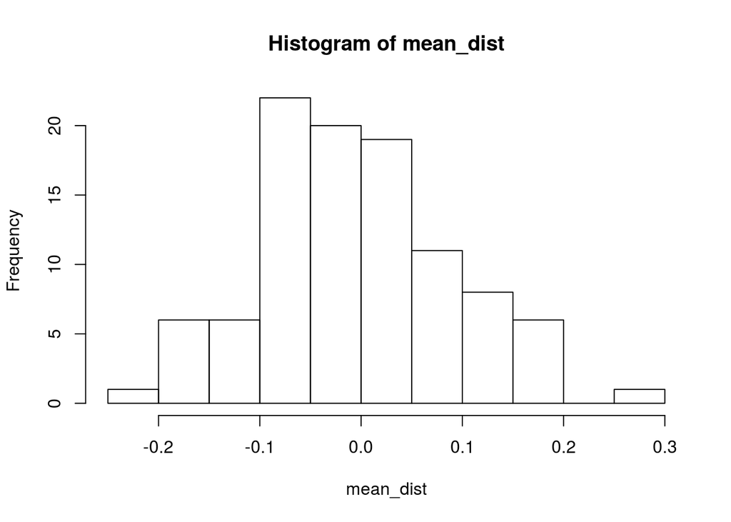

```r
hist(mean_dist)
```

Based off the histogram, we can see that our sample mean isn’t always exactly 0, but is relatively close to it. The standard deviation of our samples is 0.1 so the spread is somewhat small also. These slight variations are simply due to the variability of each of our 100 observation samples.

#### 7. (3 pts)

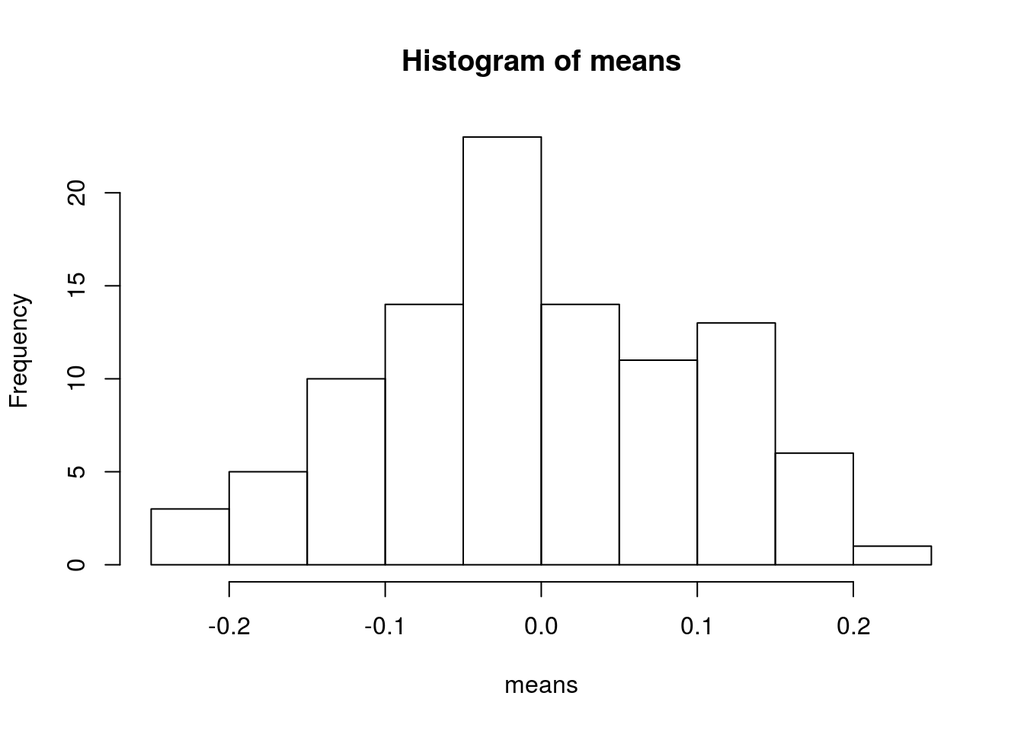

```r
HW.Bootstrap=function(distn,n,reps){
  set.seed(1848)
  means <- replicate(reps,mean(distn(n)))
  hist(means)
}

HW.Bootstrap(rnorm,100,100)
```

There’s a number of ways you could have written the function. As long as you used the `n` and `reps` function arguments, it was fine. Inputting `rnorm` as a function argument for `distn` is preferred but if your function works without doing that, it’s not an issue.

# Part 3: Linear Regression

This problem will use the Boston Housing data set. Before starting this problem, we will declare a null hypthosesis that the crime rate has no effect on the housing value for Boston suburbs. That is: H0: B1 = 0 HA: B1 =/= 0 We will attempt to reject this hypothesis by using a linear regression

Load the data

```r
housing <- read.table(url("https://archive.ics.uci.edu/ml/machine-learning-databases/housing/housing.data"),sep="")
names(housing) <- c("CRIM","ZN","INDUS","CHAS","NOX","RM","AGE","DIS","RAD","TAX","PTRATIO","B","LSTAT","MEDV")
```

#### 8. (2 pt)

Fit a linear regression using the housing data using CRIM (crime rate) to predict MEDV (median home value). Examine the model diagnostics using plot(). Would you consider this a good model or not? Explain.

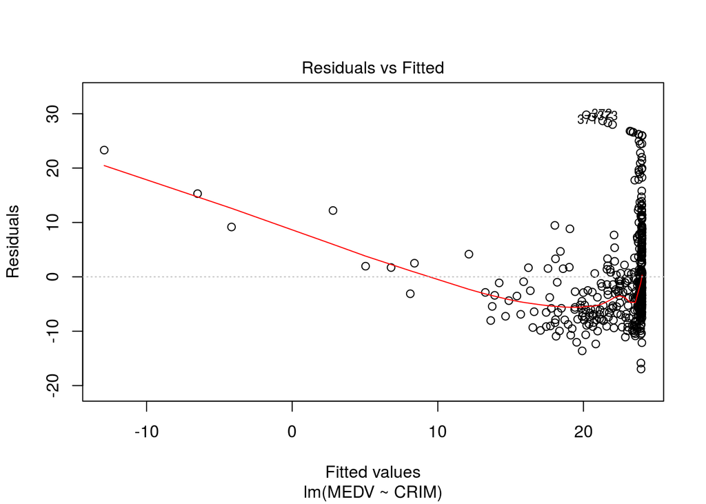

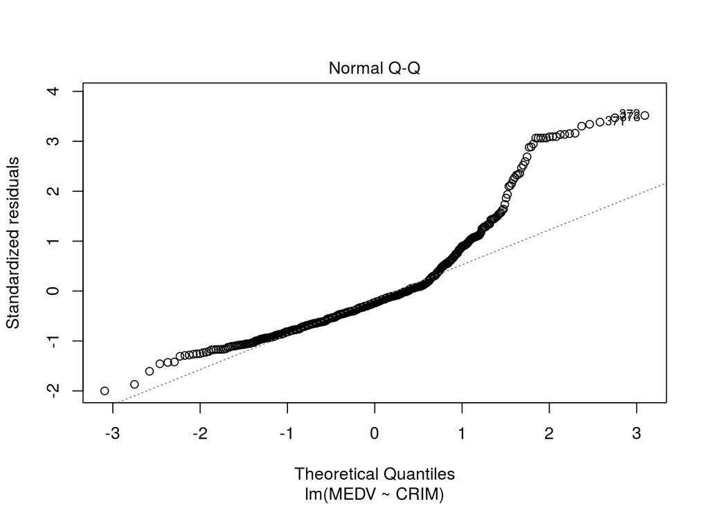

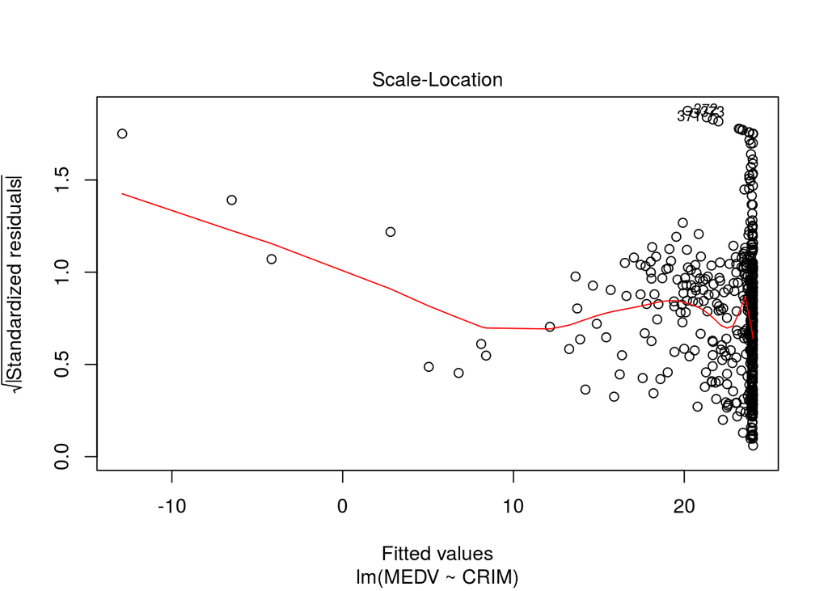

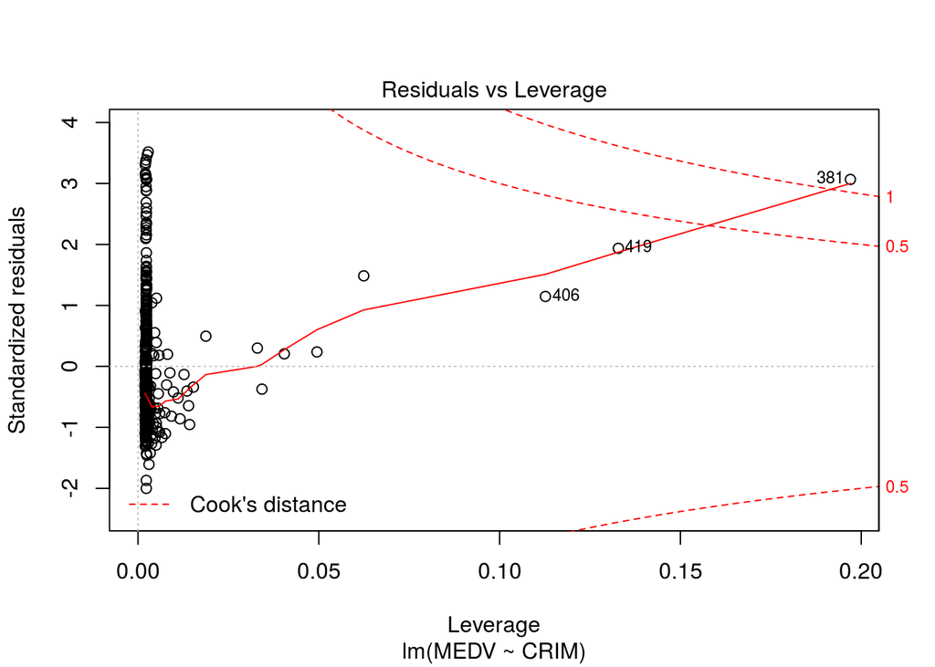

```r
model <- lm(MEDV~CRIM,data=housing)
plot(model)
```

The residuals vs fitted values is very poor (we can see a huge concentration of widely spread residuals on the right end of our fitted values). The normal Q-Q plot does not lie well on the identity line either. There is also only an $R^2$ value of approximately .15, which means our predictor variable is only accounting for 15% of the variation in our response (which leaves a lot of unexplained variance).

#### 9. (2 pts)

Using the information from summary() on your model, create a 95% confidence interval for the CRIM coefficient

```r
summary(model)
```

```
##
## Call:
## lm(formula = MEDV ~ CRIM, data = housing)
##
## Residuals:
##     Min      1Q  Median      3Q     Max
## -16.957  -5.449  -2.007   2.512  29.800
##
## Coefficients:
##             Estimate Std. Error t value Pr(>|t|)
## (Intercept) 24.03311    0.40914   58.74   <2e-16 ***
## CRIM        -0.41519    0.04389   -9.46   <2e-16 ***
## ---
## Signif. codes:  0 '***' 0.001 '**' 0.01 '*' 0.05 '.' 0.1 ' ' 1
##
## Residual standard error: 8.484 on 504 degrees of freedom
## Multiple R-squared:  0.1508, Adjusted R-squared:  0.1491
## F-statistic: 89.49 on 1 and 504 DF,  p-value: < 2.2e-16
```

```r
err <- summary(model)$coefficients[2,2]
beta <- model$coefficients[2]
c(beta-1.96*err,beta+1.96*err)
```

```
##       CRIM       CRIM
## -0.5012154 -0.3291651
```

#### 10. (2 pts)

Based on the result from question 8, would you reject the null hypothesis or not? (Assume a significance level of 0.05). Explain.

```
Since my 95% confidence interval for the estimate of B1 does not contain 0, I would reject my null hypothesis that B1=0.
```

#### 11. (1 pt)

Pretend that the null hypothesis is actually true. Based on your decision in the previous question, would you be committing a decision error? If so, which one?

```
If the null hypothesis were true, and I rejected the null as above, I would be making a type 1 decision error (rejecting H0 in favor of HA when H0 is actually true).
```

#### 12. (1 pt)

Using the variable definitions from this site: https://archive.ics.uci.edu/ml/machine-learning-databases/housing/housing.names Discuss what your regression results mean in the context of the data (using appropriate units) (Hint: Think back to Question 1)

```
For every 1 unit increase in the per capita crime rate, the median household value will decrease by about $415.
```

Your answer should have discussed the impact that X (crime rate) has on Y (house value).

#### 13. (2 pt)

Describe the LifeCycle of Data for Part 3 of this homework.

```
Answers will vary.
```